# Análisis de Siniestralidad en Seguros de Autos

Cartera de Seguros Automotrices - Mercado Mexicano

Andrés González Ortega

16 de noviembre, 2025

# 1 Resumen Ejecutivo

## 1.1 Introducción

Este informe presenta un análisis exhaustivo de una cartera de **52,000** pólizas de seguros automotrices en el mercado mexicano, con un enfoque particular en la **siniestralidad** y los factores que impactan la rentabilidad del negocio.

El análisis se basa en datos sintéticos calibrados con parámetros reales del mercado mexicano (CONDUSEF y AMIS), cubriendo el período completo de vigencia de las pólizas y registrando **2,332** eventos de siniestro.

### 1.1.1 Objetivos del Análisis

1. Evaluar la rentabilidad de la cartera a través del **Loss Ratio**
2. Identificar segmentos de alto y bajo riesgo
3. Analizar patrones temporales y geográficos de siniestralidad
4. Proporcionar recomendaciones estratégicas para optimización de la cartera

## 1.2 Indicadores Clave

| Indicador | Valor | Interpretación |
| --- | --- | --- |
| Total de Pólizas | 52,000 | Tamaño de la cartera asegurada |
| Total de Siniestros | 2,332 | Eventos de siniestro registrados |
| Prima Total Colectada | $92.1 millones MXN | Ingresos por primas de seguros |
| Monto Total Pagado en Siniestros | $45.6 millones MXN | Egresos por pagos de siniestros |
| Loss Ratio | 49.53% | ✓ Dentro del objetivo (75%) |
| Frecuencia de Siniestros | 4.48% | Porcentaje de pólizas con siniestros |
| Severidad Promedio | $27,418 MXN | Costo promedio por siniestro |

### 1.2.1 Hallazgo Principal

El **Loss Ratio** de la cartera es de **49.53%**, lo que indica que por cada peso colectado en primas, se pagan **0.50** pesos en siniestros.

**✓ Resultado:** La cartera está dentro del objetivo sectorial de 75%, indicando una operación rentable y sostenible.

# 2 Análisis de Loss Ratio

El **Loss Ratio** (Ratio de Siniestralidad) es el indicador más importante de rentabilidad en seguros. Representa la proporción entre los siniestros pagados y las primas colectadas.

## 2.1 Loss Ratio por Canal de Venta

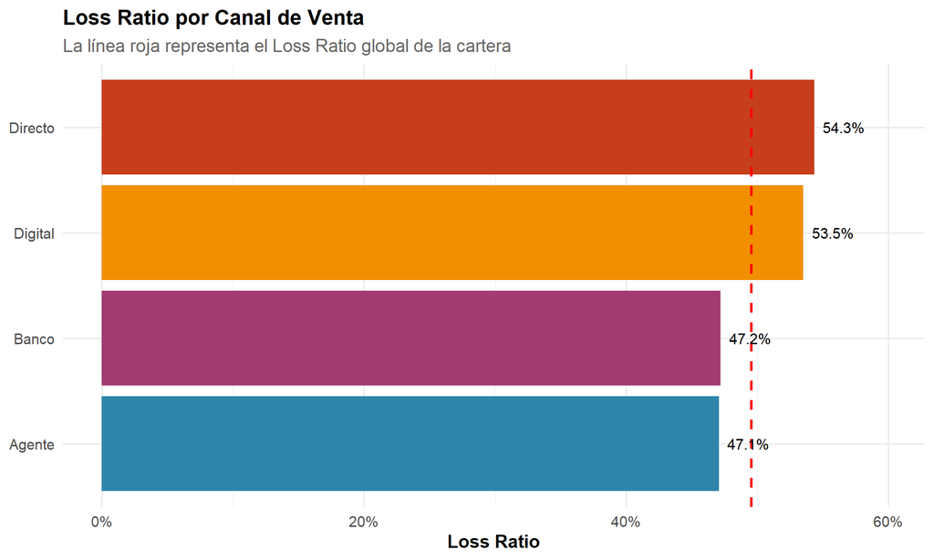

### 2.1.1 Interpretación

El análisis por canal de venta revela diferencias significativas en rentabilidad:

- **Canal con mejor desempeño:** Agente con 47.07%
- **Canal con peor desempeño:** Directo con 54.35%

**Recomendación:** Fortalecer estrategias comerciales en los canales más rentables y revisar la selección de riesgos en canales con mayor siniestralidad.

## 2.2 Loss Ratio por Tipo de Vehículo

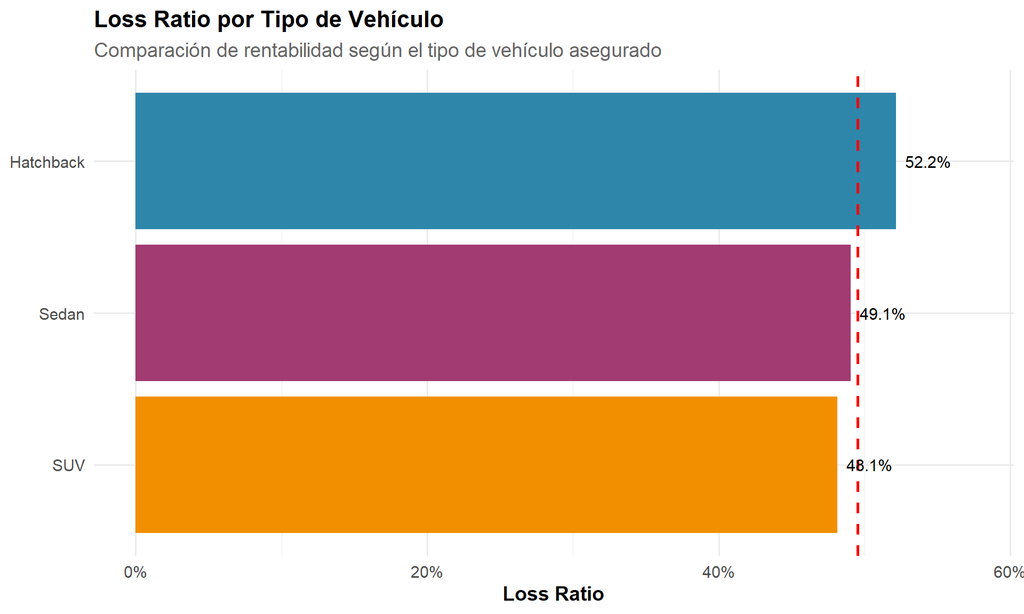

### 2.2.1 Análisis por Segmento Vehicular

| Tipo de Vehículo | Pólizas | Loss Ratio | Frecuencia |
| --- | --- | --- | --- |
| Hatchback | 11725 | 52.16% | 4.38% |
| Sedan | 34696 | 49.06% | 4.49% |
| SUV | 5579 | 48.15% | 4.68% |

Los vehículos tipo **Hatchback** presentan el Loss Ratio más alto, lo que sugiere mayor riesgo en este segmento.

# 3 Análisis de Frecuencia

La **frecuencia** mide el porcentaje de pólizas que generan al menos un siniestro. Una frecuencia global de **4.48%** significa que aproximadamente 4 de cada 100 pólizas tuvieron un siniestro.

## 3.1 Frecuencia por Rango de Edad del Conductor

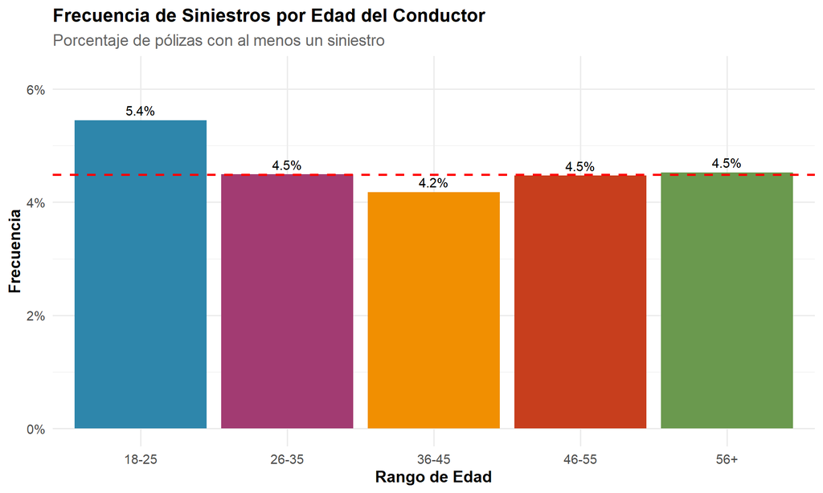

### 3.1.1 Insights por Edad

El rango de edad **18-25** muestra la frecuencia más alta (5.45%), mientras que el rango **36-45** presenta la frecuencia más baja (4.18%).

**Implicación:** Los conductores más jóvenes tienden a tener mayor frecuencia de siniestros, lo que justifica primas más altas en estos segmentos.

# 4 Análisis de Severidad

La **severidad** representa el costo promedio de cada siniestro. La cartera tiene una severidad promedio de **$27,418** MXN por siniestro.

## 4.1 Severidad por Tipo de Siniestro

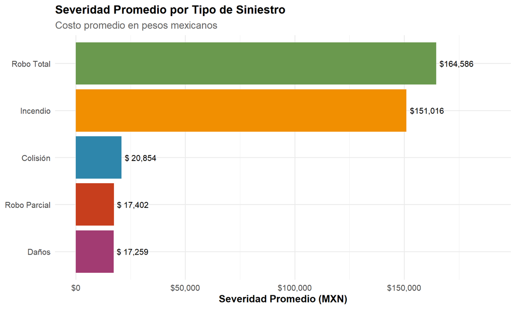

## 4.2 Distribución de Tipos de Siniestro

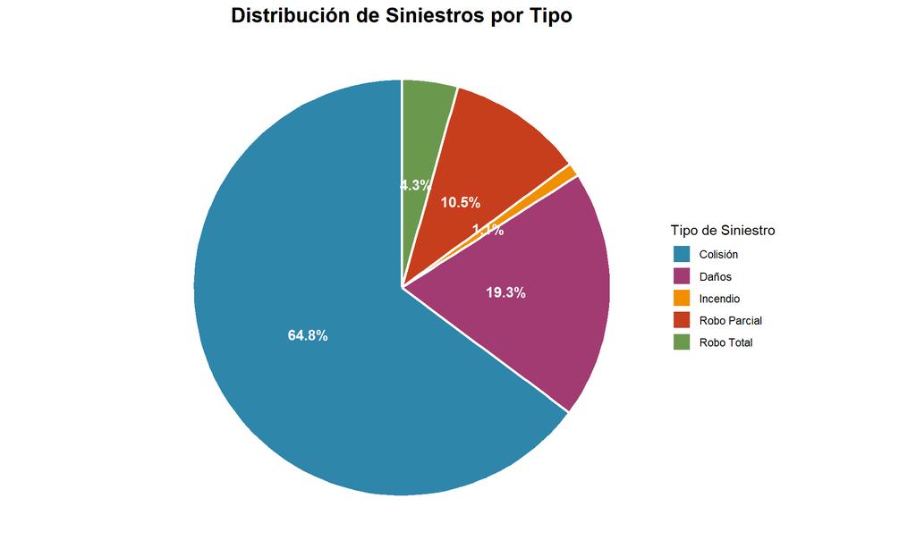

### 4.2.1 Composición de Siniestros

| Tipo de Siniestro | Cantidad | % del Total | Severidad Promedio |
| --- | --- | --- | --- |
| Robo Total | 101 | 4.3% | $164,586 |
| Incendio | 25 | 1.1% | $151,016 |
| Colisión | 1511 | 64.8% | $ 20,854 |
| Robo Parcial | 246 | 10.5% | $ 17,402 |
| Daños | 449 | 19.3% | $ 17,259 |

Los siniestros de tipo **Robo Total** son los más costosos en promedio, aunque representan solo el 4.3% del total.

# 5 Análisis Temporal

## 5.1 Tendencia Mensual de Siniestros

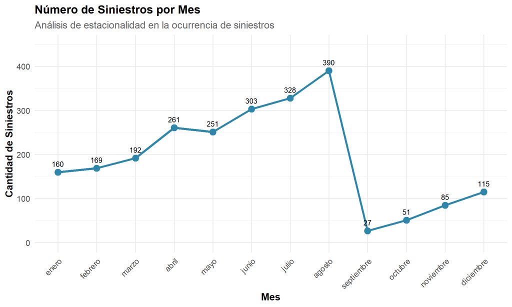

### 5.1.1 Patrones Estacionales

- **Mes con más siniestros:** agosto con 390 eventos
- **Mes con menos siniestros:** septiembre con 27 eventos
- **Variación:** 1344.4% de diferencia entre mes máximo y mínimo

**Implicación:** Existe variabilidad estacional que debe considerarse en la planificación de reservas y capacidad operativa.

# 6 Análisis Geográfico

## 6.1 Loss Ratio por Estado

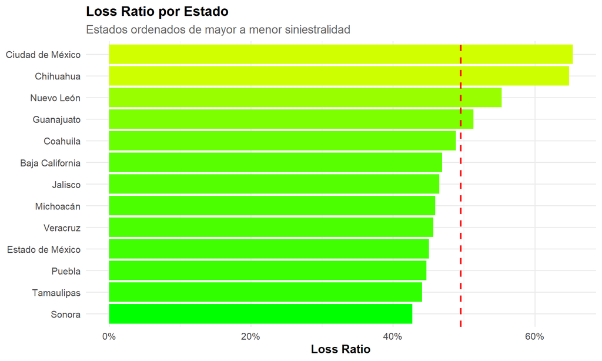

### 6.1.1 Ranking Geográfico

**Top 3 Estados con Mayor Loss Ratio:**

1. **Ciudad de México**: 65.35% - 3,191 pólizas
2. **Chihuahua**: 64.81% - 2,037 pólizas
3. **Nuevo León**: 55.32% - 2,577 pólizas

**Estados con Mejor Desempeño:**

- **Sonora**: 42.75%
- **Tamaulipas**: 44.09%

## 6.2 Penetración de Mercado

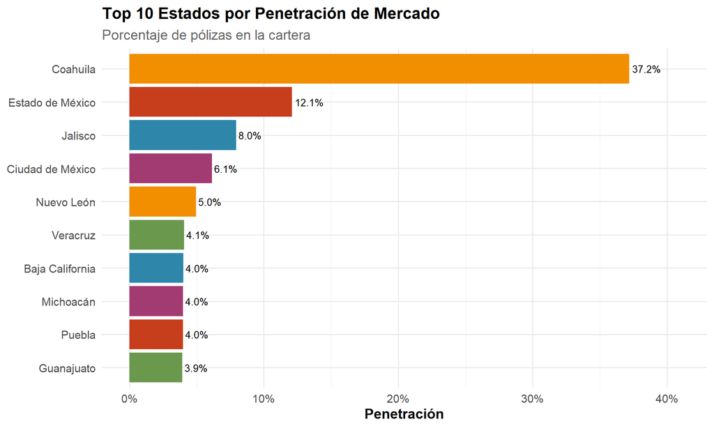

El estado de **Coahuila** concentra el 37.2% de la cartera total.

# 7 Segmentación de Riesgo

## 7.1 Matriz de Riesgo: Edad vs Tipo de Vehículo

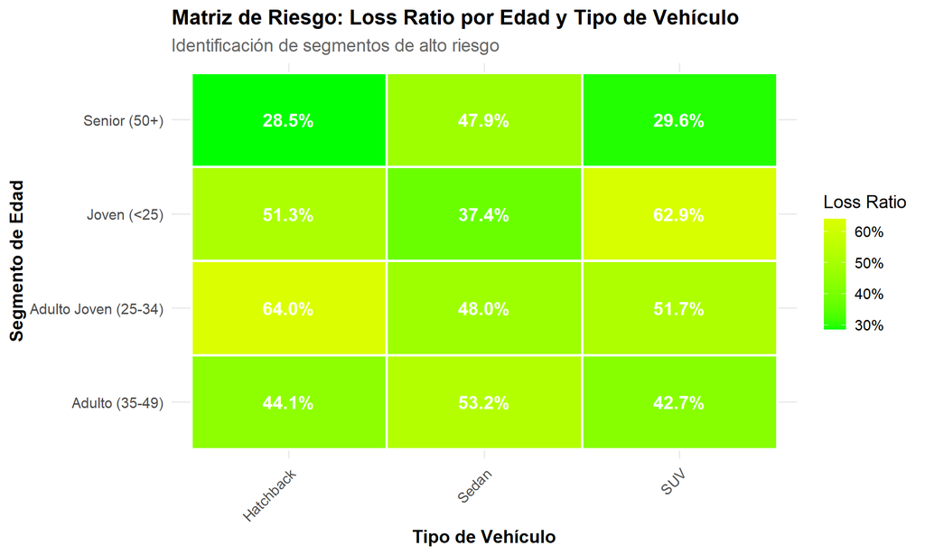

### 7.1.1 Segmentos de Alto Riesgo

| Segmento Edad | Tipo Vehículo | Pólizas | Loss Ratio |
| --- | --- | --- | --- |
| Adulto Joven (25-34) | Hatchback | 4532 | 64.04% |
| Joven (<25) | SUV | 552 | 62.95% |
| Adulto (35-49) | Sedan | 17023 | 53.17% |
| Adulto Joven (25-34) | SUV | 2076 | 51.74% |
| Joven (<25) | Hatchback | 1138 | 51.32% |

La combinación de **Adulto Joven (25-34)** con vehículos tipo **Hatchback** presenta el mayor riesgo con un Loss Ratio de 64.04%.

# 8 Conclusiones y Recomendaciones

## 8.1 Conclusiones Principales

1. **Rentabilidad General:** La cartera presenta un Loss Ratio de 49.53%, cumpliendo el objetivo sectorial del 75%.
2. **Variabilidad por Segmento:** Existen diferencias significativas en rentabilidad entre canales de venta, tipos de vehículo y regiones geográficas.
3. **Factores de Riesgo:** La edad del conductor y el tipo de vehículo son variables críticas que impactan tanto la frecuencia como la severidad.
4. **Estacionalidad:** Se observan patrones temporales con variación de 1344.4% entre el mes de mayor y menor siniestralidad.

## 8.2 Recomendaciones Estratégicas

1. **Segmentación Avanzada:** Implementar modelos predictivos de frecuencia y severidad para tarificación más precisa.
2. **Programas de Prevención:** Desarrollar iniciativas de prevención de siniestros dirigidas a conductores jóvenes.
3. **Análisis de Rentabilidad:** Monitorear mensualmente los KPIs por segmento para detección temprana de desviaciones.

### 8.2.3 A Largo Plazo

1. **Diversificación:** Balancear la cartera aumentando participación en segmentos de menor riesgo.
2. **Tecnología:** Implementar telemática para mejor evaluación de riesgo individual.
3. **Experiencia del Cliente:** Mejorar procesos de atención de siniestros para reducir costos operativos.

# 9 Anexo Técnico

## 9.1 Metodología

Este análisis se basa en:

- **Datos:** 52,000 pólizas y 2,332 siniestros
- **Período:** Cobertura completa de vigencia de pólizas
- **Calibración:** Parámetros basados en estadísticas de CONDUSEF y AMIS
- **Herramientas:** R, tidyverse, ggplot2, RSQLite

## 9.2 Definiciones

- **Loss Ratio:** Siniestros Pagados / Primas Colectadas
- **Frecuencia:** Número de Siniestros / Número de Pólizas
- **Severidad:** Monto Promedio por Siniestro
- **Penetración:** Proporción de pólizas en cada segmento

**Informe generado automáticamente el 16 de noviembre de 2025**

*Andrés González Ortega* *Proyecto: CarteraSeguroAutos*